# 🧠 Objetivo

Compreender como se comporta a diferença entre médias de duas amostras independentes retiradas de duas populações e como estimamos a variabilidade dessa diferença.

# 📌 Introdução

As análises estatísticas frequentemente se preocupam com a diferença entre médias. Um exemplo típico é um experimento projetado para comparar a média de um grupo controle com a média de um grupo experimental. A estatística inferencial utilizada na análise desse tipo de experimento depende da distribuição amostral da diferença entre médias.

A distribuição das diferenças entre médias é a distribuição amostral da diferença entre médias.

# 📐 Exemplo

Imagine que você está comparando dois grupos:

- Grupo 1: pacientes que receberam um tratamento novo.
- Grupo 2: pacientes que receberam um placebo.

Você coleta amostras aleatórias dos dois grupos e calcula suas médias.

Pergunta: A diferença entre essas médias reflete uma diferença real ou é apenas fruto da variabilidade natural das amostras?

# 📊 Conceito

Se tirássemos muitas amostras de cada grupo, calcularíamos muitas diferenças entre médias. Essas diferenças seguiriam uma distribuição amostral, chamada:

**Distribuição amostral da diferença entre médias**

Como você pode esperar, a média da distribuição amostral da diferença entre médias é:

$\mu_{M_1-M_2} = \mu_1-\mu_2$

**o que significa que a média da distribuição das diferenças entre médias amostrais é igual à diferença entre médias populacionais**. Por exemplo, digamos que a pontuação média no teste de todas as crianças de 12 anos em uma população seja 34 e a média das crianças de 10 anos seja 25. Se inúmeras amostras fossem coletadas de cada faixa etária e a diferença média fosse calculada a cada vez, a média dessas inúmeras diferenças entre as médias amostrais seria 34 - 25 = 9.

# 📊 Demonstração

Lembre-se da fórmula para a variância da distribuição amostral da média:

$\sigma^{2}_{M} = \frac{\sigma^{2}}{N}$

Assim como da fórmula do erro padrão, que é o desvio padrão das médias amostrais

Como temos duas populações e dois tamanhos de amostra, precisamos distinguir entre as duas variâncias e tamanhos de amostra. Fazemos isso usando os subscritos 1 e 2. Usando essa convenção, podemos escrever a fórmula para a variância da distribuição amostral da diferença entre médias como:

$\sigma^{2}_{M_1-M_2}=\frac{\sigma^{2}_{1}}{n_1} + \frac{\sigma^{2}_{2}}{n_2}$

A variância mede a dispersão. Se você junta duas variáveis aleatórias independentes, a dispersão total se soma — porque erros aleatórios se acumulam. Mesmo que seja uma diferença, a incerteza associada a cada uma delas contribui para a incerteza total da diferença.

Como o erro padrão de uma distribuição amostral é o desvio padrão da distribuição amostral, o erro padrão da diferença entre médias é:

$\sigma_{M_1-M_2}=\sqrt{\frac{\sigma^{2}_{1}}{n_1} + \frac{\sigma^{2}_{2}}{n_2}}$

Só para revisar a notação, o símbolo à esquerda contém um sigma ($\sigma$), o que significa que é um desvio padrão. Os subscritos $M_1 - M_2$ indicam que se trata do desvio padrão da distribuição amostral de $M_1 - M_2$.

Agora, vejamos uma aplicação desta fórmula. **Suponha que existam duas espécies de seres verdes em Marte**.

A altura média da Espécie 1 é 32, enquanto a altura média da Espécie 2 é 22. As variâncias das duas espécies são 60 e 70, respectivamente, e as alturas de ambas as espécies são normalmente distribuídas.

```python
import pandas as pd
from scipy.stats import norm
```

```python
mu_1 = 32
var_1 = 60
n_1 = 10

mu_2 = 22
var_2 = 70
n_2 = 14

species_1 = norm(mu_1, var_1 ** 0.5)
species_2 = norm(mu_2, var_2 ** 0.5)
```

Você amostra aleatoriamente 10 membros da Espécie 1 e 14 membros da Espécie 2. Qual é a probabilidade de que a média dos 10 membros da Espécie 1 exceda a média dos 14 membros da Espécie 2 em 5 ou mais? Sem fazer cálculos, você provavelmente sabe que a probabilidade é bem alta, já que a diferença nas médias populacionais é 10. Mas qual é exatamente a probabilidade?

```python
m1 = pd.Series(species_1.rvs(n_1)).mean()
m2 = pd.Series(species_2.rvs(n_2)).mean()

print(f'''
Média amostral da espécie 1: {m1:.2f}
Média amostral da espécie 2: {m2:.2f}

Diferença entre médias amostrais (1-2): {m1-m2:.2f}
''')
```

```
Média amostral da espécie 1: 34.45
Média amostral da espécie 2: 25.67

Diferença entre médias amostrais (1-2): 8.78
```

Primeiro, vamos determinar a distribuição amostral da diferença entre médias. Usando as fórmulas acima, a média é

$\mu_{M_1 - M_2}=32-22=10$

O erro padrão é:

$\sigma_{M_1-M_2}=\sqrt{\frac{60}{10} + \frac{70}{14}}=3,317$

```python
diff = norm(mu_1 - mu_2, (var_1/n_1 + var_2/n_2) ** 0.5)
```

A distribuição amostral é mostrada na Figura. Observe que ela é normalmente distribuída, com média de 10 e desvio padrão de 3,317. A área acima de 5 está sombreada em azul.

O último passo é determinar a área sombreada em azul. Usando uma tabela Z ou a calculadora normal, a área pode ser determinada como 0,934. Portanto, a probabilidade de que a média da amostra da Espécie 1 exceda a média da amostra da Espécie 2 em 5 ou mais é de 0,934.

```python
import matplotlib.pyplot as plt
import numpy as np
```

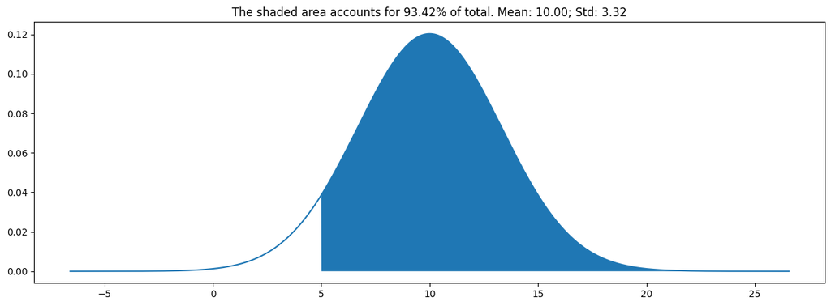

```python
def area_above(mean, std, above):
    fig, ax = plt.subplots(1, 1, figsize=(15, 5))
    x_axis = np.arange(mean-5*std, mean+5*std, 0.01)
    z = pd.Series(norm(mean, std).pdf(x_axis), index=x_axis)
    _ = z.plot(ax=ax, legend=False)
    _ = ax.fill_between(x_axis, z, 0, where=x_axis > above, interpolate=True)
    area = (1 - norm(mean, std).cdf(above)) * 100
    title = ('The shaded area accounts for {:.2f}% of total. '
             'Mean: {:.2f}; Std: {:.2f}').format(area, mean, std)
    _ = plt.title(title)

area_above(mu_1 - mu_2, (var_1/n_1 + var_2/n_2) ** 0.5, 5)
```

Como mostrado abaixo, a fórmula para o erro padrão da diferença entre médias é muito mais simples se os tamanhos amostrais e as variâncias populacionais forem iguais. Quando as variâncias e os tamanhos amostrais são iguais, não há necessidade de usar os subscritos 1 e 2 para diferenciar esses termos.

$\sigma_{M_1-M_2}=\sqrt{\frac{\sigma^{2}_{1}}{n_1} + \frac{\sigma^{2}_{2}}{n_2}}=\sqrt{\frac{\sigma^{2}}{n} + \frac{\sigma^{2}}{n}}=\sqrt{\frac{2\sigma^{2}}{n}}$

Esta versão simplificada da fórmula pode ser usada para o seguinte problema: A altura média de meninos de 15 anos (em cm) é 175 e a variância é 64. Para as meninas, a média é 165 e a variância é 64. Se oito meninos e oito meninas fossem amostrados, qual seria a probabilidade de que a altura média da amostra de meninas fosse maior que a altura média da amostra de meninos? Em outras palavras, qual seria a probabilidade de que a altura média das meninas menos a altura média dos meninos fosse maior que 0?

Como antes, o problema pode ser resolvido em termos da distribuição amostral da diferença entre médias (meninas - meninos). A média da distribuição é 165 - 175 = -10. O desvio padrão da distribuição é:

$\sigma_{M_1-M_2}=\sqrt{\frac{2\sigma^{2}}{n}}=\sqrt{\frac{128}{8}}=4$

Uma diferença entre médias de 0 ou mais é uma diferença de 10/4 = 2,5 desvios-padrão acima da média de -10. A probabilidade de uma pontuação de 2,5 ou mais desvios-padrão acima da média é de 0,0062.

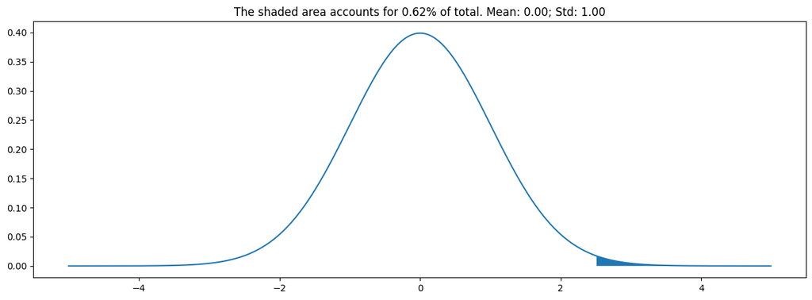

```python
area_above(0, 1, 2.5)
```

# 📚 Conclusão

A distribuição amostral da diferença entre médias é essencial para comparar grupos. Seja em testes clínicos, pesquisas de opinião ou controle de qualidade, entender essa distribuição permite avaliar se as diferenças observadas são estatisticamente significativas.